# Gaia Field Stars (CMD)

```python
import matplotlib.pyplot as plt
import numpy as np

from astropy.table import QTable, vstack
from astropy import units as u

from matplotlib.patches import Rectangle, Circle, Ellipse, Polygon

from astroquery.gaia import Gaia
```

# Instructions

### Enter the coordinates of the center of your field (`l`, `b`).

- Use a galactic longitude (`l`) of somewhere between 10 and 90 degrees
- Use a galactic latitude (`b`) of somewhere between +35 and +45 degrees

```python
my_object_l = 40
my_object_b = 40
```

## Get the the Gaia data for your field

Create and run a Gaia query to find a **high quality complete representitive sample** of 5,000 +/- 200 objects that are brighter than 17th magnutude, have a parallax SNR > 15, and have the bp-rp colors.

Adjust the radius of your search circular search window and make sure you are not cutting off any objects. See the `Note on SELECT-ORDER Bias issues` section from the HQ_Gaia notebook.

You will want the columns: `source_id, l, b, phot_g_mean_mag, bp_rp, parallax, parallax_over_error`

**Don't print out the entire object table!**

```python
my_query = f"""
SELECT TOP 5200
source_id, l, b, phot_g_mean_mag, bp_rp, parallax, parallax_over_error
FROM gaiadr3.gaia_source_lite
WHERE DISTANCE( POINT({my_object_l}, {my_object_b}), POINT(l, b) ) < 1.2
AND parallax_over_error > 15
AND phot_g_mean_mag < 17
AND bp_rp IS NOT NULL
ORDER BY parallax DESC
"""
```

```python
print(my_query)
```

```
SELECT TOP 5200
source_id, l, b, phot_g_mean_mag, bp_rp, parallax, parallax_over_error
FROM gaiadr3.gaia_source_lite
WHERE DISTANCE( POINT(40, 40), POINT(l, b) ) < 1.2
AND parallax_over_error > 15
AND phot_g_mean_mag < 17
AND bp_rp IS NOT NULL
ORDER BY parallax DESC
```

```python
my_job_query = Gaia.launch_job_async(my_query)
```

```
INFO: Query finished. [astroquery.utils.tap.core]
```

```python
print(my_job_query)
```

```
<Table length=3441>
        name         dtype  unit                            description
------------------- ------- ---- ------------------------------------------------------------------
          source_id   int64      Unique source identifier (unique within a particular Data Release)
                  l float64  deg                                                 Galactic longitude
                  b float64  deg                                                  Galactic latitude
    phot_g_mean_mag float32  mag                                              G-band mean magnitude
              bp_rp float32  mag                                                     BP - RP colour
           parallax float64  mas                                                           Parallax
parallax_over_error float32                                  Parallax divided by its standard error
Jobid: 6eabb9ba-05b8-11f1-a559-bc97e148b76b-O
Phase: COMPLETED
Owner: None
Output file: async_20260209130831.vot
Results: None
```

### How many objects did your query return?

```python
query_table = my_job_query.get_results()
np.size(query_table)
```

```
3441
```

### Use `parallax` and `phot_g_mean_mag` to get **distance** (in pc) and the **absolute magnitude** ($G_{M}$)

- Add them as columns to the data table

```python
query_table['distance'] = query_table['parallax'].to(u.parsec, equivalencies=u.parallax())
```

```python
def abs_mag(my_gmag, my_distance):
    result = my_gmag - 5 * np.log10(my_distance / (10 * u.parsec)) * u.mag
    return result

query_table['abs_gmag'] = abs_mag(my_gmag = query_table['phot_g_mean_mag'],
                                 my_distance = query_table['distance']
                               ) * u.mag

query_table.info()
```

```
<Table length=3441>
        name         dtype  unit                            description                                class
------------------- ------- ---- ------------------------------------------------------------------ ------------
          source_id   int64      Unique source identifier (unique within a particular Data Release) MaskedColumn
                  l float64  deg                                                 Galactic longitude MaskedColumn
                  b float64  deg                                                  Galactic latitude MaskedColumn
    phot_g_mean_mag float32  mag                                              G-band mean magnitude MaskedColumn
              bp_rp float32  mag                                                     BP - RP colour MaskedColumn
           parallax float64  mas                                                           Parallax MaskedColumn
parallax_over_error float32                                  Parallax divided by its standard error MaskedColumn
           distance float64   pc                                                           Parallax       Column
           abs_gmag float64  mag                                                                          Column
```

## Make a subset of all of the *white dwarf* stars in your field

- You will need information from the CMD on the back your Gaia Info Sheet.
- You will need to make a cut based on the color (`bp_rp`) and Absolute magnitude (G$_M$).
- It may be easier to make a few smaller tables and combine them.

```python
subset1 = query_table[(query_table['bp_rp'] < 1.7) &
                            (query_table['bp_rp'] > -0.75) &
                        (query_table['phot_g_mean_mag'] > 13) &
                        (query_table['phot_g_mean_mag'] < 17)
                           ]

subset2 = query_table[(query_table['bp_rp'] < 0.8) &
                        (query_table['bp_rp'] > -0.7) &
                        (query_table['phot_g_mean_mag'] > 12) &
                        (query_table['phot_g_mean_mag'] < 13)]

subset3 = query_table[(query_table['bp_rp'] > -0.75) &
                        (query_table['bp_rp'] < 0.6) &
                        (query_table['phot_g_mean_mag'] < 12) &
                        (query_table['phot_g_mean_mag'] > 9)]

subset4 = query_table[(query_table['bp_rp'] > -0.85) &
                    (query_table['bp_rp'] < -0.75) &
                    (query_table['phot_g_mean_mag'] > 7) &
                    (query_table['phot_g_mean_mag'] < 9)]
```

```python
white_dwarfs = vstack([subset1, subset2, subset3, subset4])
```

### How many of your objects are white dwarf stars?

```python
np.size(white_dwarfs)
```

```
2658
```

## Make a subset of the 300 nearest stars

```python
query_table.sort('distance')
nearest_stars = query_table[0:300]
np.size(nearest_stars)
```

```
300
```

## Make a subset of the 300 most distant stars

```python
farthest_stars = query_table[-300:]
np.size(farthest_stars)
```

```
300
```

# Create the following plot

- All on one page using `.subplot_mosaic`
- Total size 12 inches wide, 15 inches high
- With the following relative proportions:

```
          --------------------
          |                  |
          |                  |
          |                  |
          |                  |
          |      Plot A      |
          |                  |
          |                  |
          |                  |
          |                  |
          --------------------
          |                  |
          |     Plot B       |
          --------------------
```

- Both axes labeled
- A title for the figure
- Plot all of the stars
- A symbol and label placed at the position of the Sun (**bp_rp** = 0.82, $G_{M}$ = 4.67)
- White dwarf stars plotted with a different symbol, color, and size
- 300 nearest stars plotted with a different symbol, color, and size
- 300 most distant stars plotted with a different symbol, color, and size
- **Use annotations (arrows, shapes, text) to make everything clear**

## Plot B - A histrogram of the `bp_rp` colors of the stars in your field.

- Three histograms on the same plot
  - Set the Y-axis to `log`
  - Use a bin size of 0.1 mag
  - A histogram of **ALL** of the stars in the field
  - A histogram of the 300 nearest stars in the field (in a different color)
  - A histogram of the 300 most distant stars in the field (in a different color)
- All three histograms should be clearly labeled and easy to distinguish
- Both axes labeled

[figure not shown]

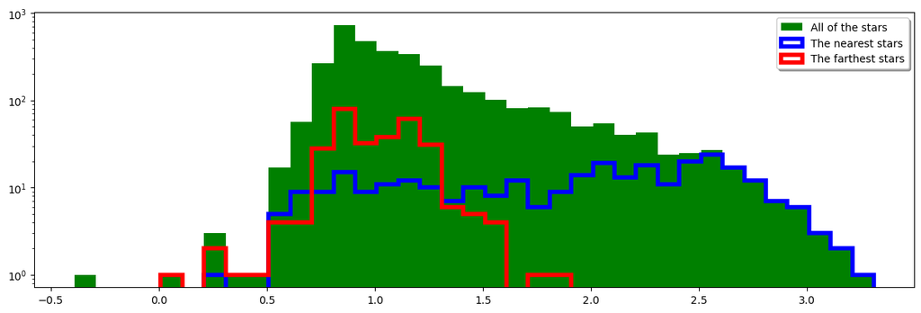

```python
#Plot A: CMD info
fig, ax = plt.subplots(
    figsize = (8, 10),
    constrained_layout = True
)

ax.set_aspect(1 / 4)

ax.set_ylim(2,18)
ax.invert_yaxis()

ax.tick_params(axis='both', which='major', labelsize = 18)

###

sun_color = [0.82]
sun_gmag = [4.67]

ax.set_xlabel("BP - RP (color)",
              fontfamily = 'serif',
              fontsize = 25)

ax.set_ylabel("Photometric G Mags",
              fontfamily = 'serif',
              fontsize = 25)

ax.set_title("CMD of a Gaia Field",
             fontfamily = 'serif',
             fontsize = 30)

#Plotting the Sun's datapoint
ax.plot(sun_color, sun_gmag,
        color = "DarkOrange",
        marker = "*",
        linestyle = "None",
        markersize = 25
       );

ax.annotate('The Sun',
             xy = (0.82, 4.67),
             xytext = (0, 5),
             fontsize = 10,
             color = 'DarkOrange',
             arrowprops = {'color' : 'Coral',
                           'linewidth' : 3,
                           'arrowstyle' : '->, head_length = 0.5, head_width = 0.2',
                           'connectionstyle' : 'angle3, angleA = 90, angleB = 0'}
           );

#Plotting the CMD
ax.plot(query_table['bp_rp'], query_table['phot_g_mean_mag'],
        color = 'green',
        marker = "x",
        linestyle = "None",
        markersize = 1
);

ax.plot(white_dwarfs['bp_rp'], white_dwarfs['phot_g_mean_mag'],
        color = "#4C0B5F",
        marker = "+",
        linestyle = "None",
        markersize = 1.5
       );

ax.plot(nearest_stars['bp_rp'], nearest_stars['phot_g_mean_mag'],
        color = 'blue',
        marker = "o",
        linestyle = "None",
        markersize = 2
);

ax.plot(farthest_stars['bp_rp'], farthest_stars['phot_g_mean_mag'],
        color = 'red',
        marker = "D",
        linestyle = "None",
        markersize = 2
);

#Annotations of Plot A
ax.annotate('The dimmest nearby star',
             xy = (1.1, 2.5),
             xytext = (-0.5, 2.5),
             fontsize = 10,
             color = 'blue',
             arrowprops = {'color' : 'blue',
                           'linewidth' : 1.5,
                           'arrowstyle' : '->, head_length = 0.25, head_width = 0.1',
                           'connectionstyle' : 'angle3, angleA = 90, angleB = 0'}
           );

ax.annotate('A random field star',
             xy = (0.6, 10.15),
             xytext = (-0.3, 10.15),
             fontsize = 10,
             color = 'green',
             arrowprops = {'color' : 'green',
                           'linewidth' : 1.5,
                           'arrowstyle' : '->, head_length = 0.25, head_width = 0.1',
                           'connectionstyle' : 'angle3, angleA = 90, angleB = 0'}
           );

ax.annotate('Some distant star',
             xy = (0.3, 14.4),
             xytext = (-0.5, 14.4),
             fontsize = 10,
             color = 'red',
             arrowprops = {'color' : 'red',
                           'linewidth' : 1.5,
                           'arrowstyle' : '->, head_length = 0.25, head_width = 0.1',
                           'connectionstyle' : 'angle3, angleA = 90, angleB = 0'}
           );

ax.annotate('A white dwarf',
             xy = (0.5, 11.7),
             xytext = (-0.3, 11.7),
             fontsize = 10,
             color = 'purple',
             arrowprops = {'color' : 'purple',
                           'linewidth' : 1.5,
                           'arrowstyle' : '->, head_length = 0.25, head_width = 0.1',
                           'connectionstyle' : 'angle3, angleA = 90, angleB = 0'}
           );

#Plot B: Histogram


fig, ax = plt.subplots(
    figsize = (12, 4),
    constrained_layout = True
)


#All stars
ax.set_yscale("log")

all_bins = np.arange(query_table['bp_rp'].min(), query_table['bp_rp'].max() + 0.1, 0.1)

ax.hist(query_table['bp_rp'],
        bins = all_bins,
        histtype = 'stepfilled',
        facecolor = 'green',
        label = "All of the stars")

ax.hist(nearest_stars['bp_rp'],
        bins = all_bins,
        histtype = 'step',
        color = 'blue',
        linewidth = 4,
        label = "The nearest stars")

ax.hist(farthest_stars['bp_rp'],
        bins = all_bins,
        histtype = 'step',
        color = 'red',
        linewidth = 4,
        label = "The farthest stars")

ax.legend(loc=0, shadow=True)
```

### Save and download a PNG version of your figure. You will need this for the final assignment of the class.

- Feel free to change the name of the file if you wish.

```python
fig.savefig('FieldCMD.png', bbox_inches='tight')
```

### Due Mon Feb 9 - 1 pm

- `File -> Download as -> HTML (.html)`
- `upload your .html file to the class Canvas page`